# Mann-Whitney Test Using R (Using RStudio)

Mann-Whitney Test Using R (Using RStudio)

A Mann-Whitney test is used to assess whether the values of an Ordinal outcome variable differ between two groups.

**Example:**

We might ask participants if they agree with a statement in a questionnaire, responding using a 5-point Likert scale:

1. Strongly Disagree
2. Disagree
3. Neither disagree nor agree
4. Agree
5. Strongly Agree

We wish to see if males agree more than females or vice-versa.

These coded responses 1 to 5 do not represent a scale but instead are ordered categories and so that data is Ordinal.

**Comparing groups for ordinal outcomes**

Since we want to compare two groups for an ordinal outcome we could use a Mann-Whitney test. To compare more than two groups, consider using a Kruskal Wallis test.

A Mann-Whitney test can also be used when the outcome variable is Scale (e.g. calorie intake or blood pressure etc.) but a better test would be a Two Sample t-test. However, that t-test test makes an assumption about normality and if that assumption is in doubt, then a Mann-Whitney test would be a good alternative.

For more help on “What test do I need” go to the **sigma** website [statistical worksheets resources](https://libguides.coventry.ac.uk/c.php?g=712076&p=5146769) page.

## Example

A study asked participants to rate various aspects of a new mobile phone, on an ordinal scale of 1 to 10 where 1 indicated they felt this aspect had “low importance”, up to 10 to indicate “high importance”. The data shown below can be downloaded in an CSV file called phone.csv and shows columns for the rating scores for price, ease of use, look, etc.

[figure not shown]

We are interested in whether the price rating tends to be higher or lower amongst males compared to females. Since the price score is Ordinal and we wish to compare two groups we should use a Mann-Whitney test.

## Importing the data into R

To get started with the analysis, first, bring the dataset into RStudio. To do this you can either run a read.csv() function if you know how to do this or alternatively you can follow the following steps using the menus:

From the **File** menu select **Import Dataset** then **From Text(base)**:

[figure not shown]

From the pop-up window navigate to the folder **where you have saved the dataset**, then once the file was selected click “Open”:

[figure not shown]

At the next dialogue box (see below), in the upper left corner in the **“Name”** field, amend the name of your dataset if you wish, in this example we named it as **“phone”**.

We should also make sure the **Heading** option below is set to **Yes** (otherwise the data will all be read in as text):

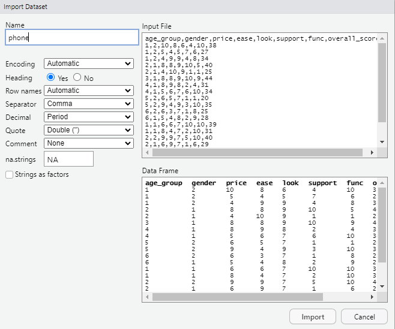

Finally, click on **“Import”** to complete the process. This imports the data set and is listed in the **“Environment”** in the top right of your RStudio screen as follows:

[figure not shown]

## Using RStudio

To carry out a Mann-Whitney test, we can use the **wilcox.test()** function. First specify the **outcome variable** (price), followed by the **grouping variable** (gender).

```r
wilcox.test(price ~ gender, data=phone)
```

To see if males or females tended to rate price more importantly, you can obtain the median scores as follows:

```r
median(phone$price[phone$gender==1])
median(phone$price[phone$gender==2])
```

Note: We indicate which variables we want to use by typing type the name of our dataset followed by a dollar sign **“$”** and the name of our column that contains the data.

We do this twice, once for each gender, by specifying the data to include in each calculation. Specifying **phone$gender==1** allows for only data for males to be included.

## Examining the Output

The Research Question is: Is there a difference in the price scores for males and females?

**The Mann-Whitney test answers this by testing the hypotheses:**

H0: There is no difference in the distribution of price scores

H1: There is a difference in the distribution of price scores

The output below provides the main results of our test:

```
##
##  Wilcoxon rank sum test with continuity correction
##
## data:  price by gender
## W = 390.5, p-value = 0.02301
## alternative hypothesis: true location shift is not equal to 0
```

The p-value is 0.023, which is less than 0.05 so there is evidence in favour of H1 that is there is a difference in the price scores between males and females.

The median scores obtained are as follows:

```r
median(phone$price[phone$gender==1])
```

```
## [1] 7
```

```r
median(phone$price[phone$gender==2])
```

```
## [1] 8
```

## Reporting Results

**We could report the results as:**

*“A Mann-Whitney t-test was used to compare the price scores for males and females. The difference was statistically significant (p = 0.023) and females tended to score price as more important (Median = 8) compared to males (Median = 7).“*

## Closing Note

Whilst we often report medians in the results section when using a Mann-Whitney test, the test does not formally test whether there is a difference in the medians between the two groups, despite large amounts of information on the internet incorrectly suggesting it does. The test actually compares the distribution of the Ordinal outcome between two groups.

For more resources, see sigma.coventry.ac.uk Adapted from material developed by Coventry University